# Lab Session: Unsupervised Learning - Clustering

Class 8

## Lab: K-Means and Hierarchical Clustering

In this lab, we will explore two common unsupervised clustering methods: Hierarchical Clustering and K-Means. Our goal is to discover natural groupings within a dataset of European countries based on their employment percentages in different industries.

```r
rm(list = ls())
pacman::p_unload(pacman::p_loaded())
pacman::p_load(tidyverse, cluster, factoextra, here, knitr)
```

### Data, EDA, & Scaling

First, we’ll load the `Eurojobs` dataset. This dataset contains the percentage of the workforce employed in nine different industries for 26 European countries in 1979. It contains 10 variables:

- `Country`: the name of the country (identifier)
- `Agr`: % of workforce employed in agriculture
- `Min`: % in mining
- `Man`: % in manufacturing
- `PS`: % in power supplies industries
- `Con`: % in construction
- `SI`: % in service industries
- `Fin`: % in finance
- `SPS`: % in social and personal services
- `TC`: % in transportation and communications

We will perform some basic exploratory data analysis (EDA) and then—most importantly—scale the data. Scaling is crucial for distance-based algorithms like K-Means and Hierarchical Clustering, as it ensures that variables with larger ranges (e.g., Agriculture) don’t dominate the clustering process over variables with smaller ranges (e.g., Mining).

```r
# Load the data from the URL provided in the inspiration HTML file
data_url <- "https://statsandr.com/blog/data/Eurojobs.csv"
Eurojobs <- read.csv(data_url, row.names = 1) # Use first column as row names
print(summary(Eurojobs))
```

```
##       Agr             Min             Man              PS
##  Min.   : 2.70   Min.   :0.100   Min.   : 7.90   Min.   :0.1000
##  1st Qu.: 7.70   1st Qu.:0.525   1st Qu.:23.00   1st Qu.:0.6000
##  Median :14.45   Median :0.950   Median :27.55   Median :0.8500
##  Mean   :19.13   Mean   :1.254   Mean   :27.01   Mean   :0.9077
##  3rd Qu.:23.68   3rd Qu.:1.800   3rd Qu.:30.20   3rd Qu.:1.1750
##  Max.   :66.80   Max.   :3.100   Max.   :41.20   Max.   :1.9000
##       Con               SI             Fin              SPS
##  Min.   : 2.800   Min.   : 5.20   Min.   : 0.500   Min.   : 5.30
##  1st Qu.: 7.525   1st Qu.: 9.25   1st Qu.: 1.225   1st Qu.:16.25
##  Median : 8.350   Median :14.40   Median : 4.650   Median :19.65
##  Mean   : 8.165   Mean   :12.96   Mean   : 4.000   Mean   :20.02
##  3rd Qu.: 8.975   3rd Qu.:16.88   3rd Qu.: 5.925   3rd Qu.:24.12
##  Max.   :11.500   Max.   :19.10   Max.   :11.300   Max.   :32.40
##        TC
##  Min.   :3.200
##  1st Qu.:5.700
##  Median :6.700
##  Mean   :6.546
##  3rd Qu.:7.075
##  Max.   :9.400
```

Now, we scale the data. We’ll use the `scale()` function, which standardizes each column to have a mean of 0 and a standard deviation of 1.

```r
# scale the data
Eurojobs_scaled <- scale(Eurojobs)
print(summary(as.data.frame(Eurojobs_scaled)))
```

```
##       Agr               Min               Man                 PS
##  Min.   :-1.0569   Min.   :-1.1895   Min.   :-2.72665   Min.   :-2.1469
##  1st Qu.:-0.7353   1st Qu.:-0.7514   1st Qu.:-0.57189   1st Qu.:-0.8179
##  Median :-0.3011   Median :-0.3132   Median : 0.07739   Median :-0.1533
##  Mean   : 0.0000   Mean   : 0.0000   Mean   : 0.00000   Mean   : 0.0000
##  3rd Qu.: 0.2923   3rd Qu.: 0.5630   3rd Qu.: 0.45554   3rd Qu.: 0.7105
##  Max.   : 3.0662   Max.   : 1.9032   Max.   : 2.02523   Max.   : 2.6376
##       Con                SI               Fin               SPS
##  Min.   :-3.2605   Min.   :-1.6956   Min.   :-1.2471   Min.   :-2.15579
##  1st Qu.:-0.3892   1st Qu.:-0.8104   1st Qu.:-0.9888   1st Qu.:-0.55246
##  Median : 0.1122   Median : 0.3152   Median : 0.2316   Median :-0.05463
##  Mean   : 0.0000   Mean   : 0.0000   Mean   : 0.0000   Mean   : 0.00000
##  3rd Qu.: 0.4920   3rd Qu.: 0.8562   3rd Qu.: 0.6859   3rd Qu.: 0.60061
##  Max.   : 2.0264   Max.   : 1.3425   Max.   : 2.6010   Max.   : 1.81226
##        TC
##  Min.   :-2.4048
##  1st Qu.:-0.6081
##  Median : 0.1106
##  Mean   : 0.0000
##  3rd Qu.: 0.3801
##  Max.   : 2.0510
```

### Hierarchical Clustering

Hierarchical (or agglomerative) clustering builds a “bottom-up” hierarchy of clusters. It starts with each observation as its own cluster and progressively merges the closest pairs of clusters until all observations are in a single cluster.

We will: 1. Calculate a distance matrix for our scaled data. 2. Run the hierarchical clustering algorithm (using “complete” linkage). 3. Plot the resulting dendrogram to visualize the cluster hierarchy.

```r
dist_matrix <- dist(Eurojobs_scaled, method = "euclidean")
```

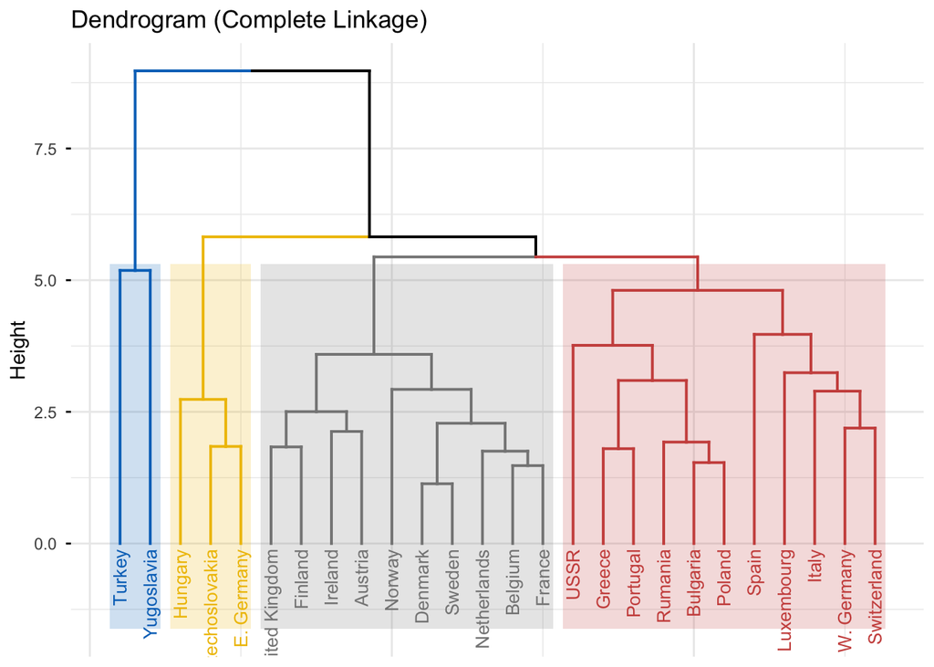

```r
# other methods include "average", "single", and "centroid"
hc_complete <- hclust(dist_matrix, method = "complete")

# plot the dendrogram - basic
# plot(hc_complete, main = "Complete Linkage Dendrogram", xlab = "", sub = "")

# fviz_dend from factoextra gives a nicer, clearer plot
fviz_dend(hc_complete,
          main = "Dendrogram (Complete Linkage)",
          cex = 0.7, # Label size
          k = 4, # Cut the tree into 4 clusters
          rect = TRUE, # Add rectangles around the clusters
          rect_border = "jco",
          rect_fill = TRUE,
          palette = "jco",
          ggtheme = theme_minimal())
```

Looking at the dendrogram, we can decide where to “cut” the tree to form clusters. For example, a cut at a height of ~5.0 would give us 4 distinct clusters. We can get the cluster assignments for each country using the `cutree()` function.

```r
# cut the tree to get 4 clusters
clusters_hc <- cutree(hc_complete, k = 4)

# Show which countries are in which cluster
Eurojobs_clustered_hc <- Eurojobs %>%
  mutate(Cluster = as.factor(clusters_hc))

cat("\n--- Countries by Cluster (Hierarchical) ---\n")
```

```
##
## --- Countries by Cluster (Hierarchical) ---
```

```r
# Print countries for each cluster
for(i in 1:4) {
  cat(paste("\nCluster", i, ":\n"))
  print(rownames(Eurojobs_clustered_hc[Eurojobs_clustered_hc$Cluster == i, ]))
}
```

```
##
## Cluster 1 :
##  [1] "Belgium"        "Denmark"        "France"         "Ireland"
##  [5] "Netherlands"    "United Kingdom" "Austria"        "Finland"
##  [9] "Norway"         "Sweden"
##
## Cluster 2 :
##  [1] "W. Germany"  "Italy"       "Luxembourg"  "Greece"      "Portugal"
##  [6] "Spain"       "Switzerland" "Bulgaria"    "Poland"      "Rumania"
## [11] "USSR"
##
## Cluster 3 :
## [1] "Turkey"     "Yugoslavia"
##
## Cluster 4 :
## [1] "Czechoslovakia" "E. Germany"     "Hungary"
```

### K-Means & Gap Statistic

K-Means clustering is a “top-down” approach where we must specify the number of clusters, `k`, in advance. The algorithm then partitions the data into `k` clusters, minimizing the within-cluster sum of squares.

1. **Silhouette Method:** Measures how similar an observation is to its own cluster compared to other clusters. We look for the `k` with the highest average silhouette score.
2. **Gap Statistic:** Compares the WSS of our data to the WSS of randomly generated “null” reference datasets. We pick the `k` that maximizes this “gap.”

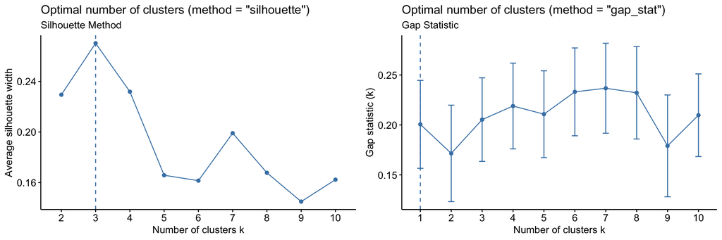

```r
# seed for reproducible results
set.seed(42)
# silhouette Method
p2 <- fviz_nbclust(Eurojobs_scaled, kmeans, method = "silhouette") +
  labs(subtitle = "Silhouette Method")

# gap Statistic Method
# We use nboot = 50 to speed it up for the lab.
# For a real analysis, nboot = 500 or more is better.
p3 <- fviz_nbclust(Eurojobs_scaled, kmeans,
                   method = "gap_stat",
                   nboot = 50) +
  labs(subtitle = "Gap Statistic")

# Display plots side-by-side
gridExtra::grid.arrange(p2, p3, nrow = 1)
```

Now, let’s run our final K-Means algorithm with `k=` 7.

```r
# Set seed for reproducibility
set.seed(42)
# Perform k-means clustering with k = 3
km_final <- kmeans(Eurojobs_scaled, centers = which.max(p3$data$gap))
```

```r
# add K-Means cluster assignments to the original data
Eurojobs_clustered_km <- Eurojobs %>%
  mutate(Cluster = as.factor(km_final$cluster))

cat("\n--- Countries by Cluster (K-Means) ---\n")
```

```
##
## --- Countries by Cluster (K-Means) ---
```

```r
# Print countries for each cluster
for(i in 1:which.max(p3$data$gap)) {
  cat(paste("\nCluster", i, ":\n"))
  print(rownames(Eurojobs_clustered_km[Eurojobs_clustered_km$Cluster == i, ]))
}
```

```
##
## Cluster 1 :
## [1] "France"      "W. Germany"  "Luxembourg"  "Austria"     "Spain"
## [6] "Switzerland"
##
## Cluster 2 :
## [1] "Ireland"  "Italy"    "Greece"   "Portugal"
##
## Cluster 3 :
## [1] "Belgium"        "Denmark"        "Netherlands"    "United Kingdom"
## [5] "Finland"        "Norway"         "Sweden"
##
## Cluster 4 :
## [1] "Czechoslovakia" "E. Germany"     "Hungary"
##
## Cluster 5 :
## [1] "Bulgaria" "Poland"   "Rumania"  "USSR"
##
## Cluster 6 :
## [1] "Turkey"
##
## Cluster 7 :
## [1] "Yugoslavia"
```